# blancocentR

# A package for Blanco Center staff

```r
library(blancocentR)
```

This package includes resources to help achieve a cohesive look for Blanco Center data visualizations. The main use of blancocentR is in conjunction with ggplot2, but colors can be used across other tools, and the included data can be useful for applications that don’t involve data visualizations.

## The data

BlancocentR includes two data objects that should help working with Louisiana’s 64 parishes and region designations by different state agencies or other organizations: While the tibble `parishes` includes the parishes and regions, `louisiana` is an sf object which includes population estimates, geometry, and center points for each parish in addition to what is included in `parishes`.

You can access the data via `blancocentR::parishes` and `blancocentR::louisiana`, or you can load them into your environment. Let’s load both!

```r
data(parishes)
data(louisiana)
```

We can now plot a simple map of Louisiana with outlines for each parish.

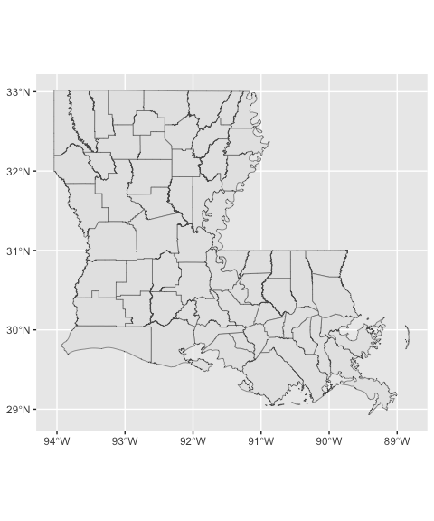

```r
library(ggplot2)

p1 <- ggplot(louisiana) + geom_sf()
p1
```

We can use the ‘fill’ aesthetic to designate different regions, e.g., DCFS regions.

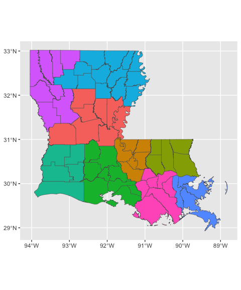

```r
p2 <- ggplot(louisiana) + geom_sf(aes(fill = region_name_DCFS), show.legend = FALSE)
p2
```

## Getting region polygons

Sometimes it’s useful to not only have the parish polygons but also region polygons. Maybe you’d like to map Louisiana’s parishes and show region boundaries without using ‘fill’ for regions. Maybe you’d like to plop each region’s name in the center of their area. We can do that using `get_region_geometry()`. Let’s use DCFS regions again for this example!

```r
dcfs_regions <- get_region_geometry(louisiana, region_DCFS, region_name_DCFS)
```

Our sf object has changed from 64 observations (one for each parish) to 9 observations (one for each DCFS region). Let’s plot a map!

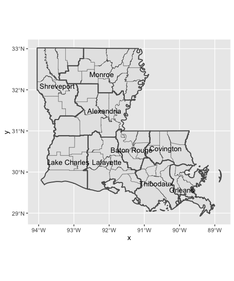

```r
ggplot(dcfs_regions) +
  geom_sf(data = louisiana) + # parish boundaries
  geom_sf(lwd = 0.7, fill = NA) + # region boundaries
  geom_sf_text(aes(label = region_name_DCFS)) # region names
```

## The theme

BlancocentR includes the Blanco Center theme, `theme_bc()`. The theme defines the use of font families, sizes, and colors for different aspects of the plot structure. The base text is defined as using the *sans serif* font (“Quicksand”) in size 12 and color `light_text` (“#575E66”). The plot structure (e.g., axis lines, ticks, and text) all use the color `light_text` as well, only titles (plot title, legend title, and axis titles) are more emphasizes by using *serif* font “Bitter” and the color `dark_text`. For extra emphasis and ULL color branding, the plot title uses `ull_red` (“#a00b0b”). The default position for the legend defined by this theme is on top of the plot in a horizontal direction but that can be changed as needed. You can customize the theme by changing its arguments.

Let’s create some additional example plots to use throughout this tutorial.

```r
library(scales)
p3 <- ggplot(louisiana) +
  geom_point(
    aes(x = estimate, y = region_name_DCFS, color = region_name_DCFS),
    size = 3) +
  scale_x_continuous(labels = label_number(scale_cut = cut_short_scale())) +
  labs(title = "Louisiana population in 2023",
       subtitle = "Parish population by DCFS region",
       caption = "Source: U.S. Census, 2023 ACS 5-Year estimates, Table B01003",
       y = NULL,
       x = NULL)
```

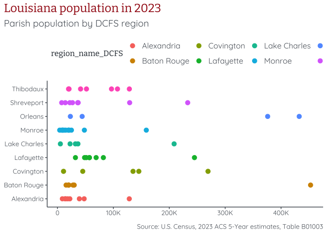

```r
p3 +
  theme_bc()
```

### Grid lines

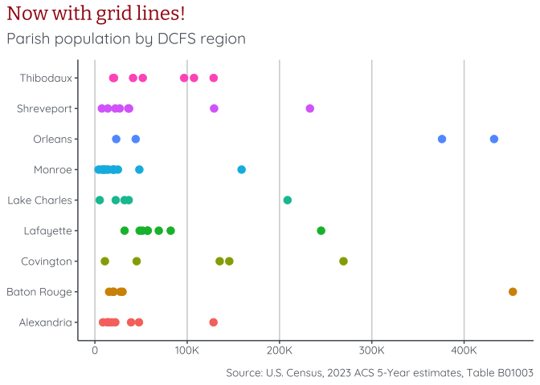

```r
p3 + labs(title = "Now with grid lines!") +
  theme_bc(grid_x = TRUE) +
  theme(legend.position = "none") # remove legend
```

### Void

Most maps look better without any axes. We can take advantage of the ‘void’ argument to remove all axes in one simple step.

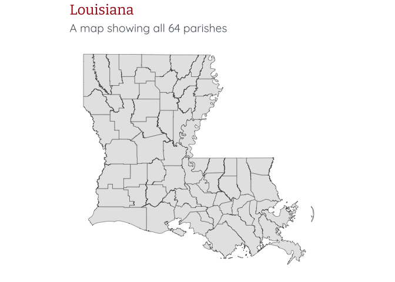

```r
p1 +
  labs(title = "Louisiana",
       subtitle = "A map showing all 64 parishes") +
  theme_bc(void = TRUE)
```

## The colors

This package includes several color palettes, list of named colors, and individual colors. Please note that accessing some of the colors may be different when you use this package from your experience sourcing colors from R scripts.

### Named colors

Named colors are accessible once you’ve loaded this package without showing up in your environment.

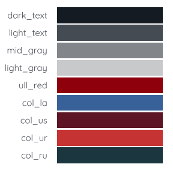

### Miscellaneous colors

Miscellaneous colors are still available by name. You can call any specific color from this collection by naming it specifically, e.g., `misc_pal$jadegreen`, or print the whole list by calling `misc_pal`.

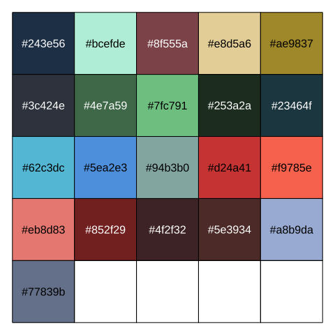

```r
library(scales)

list(
  # row 1
  "midnight" = "#243e56",
  "mint" = "#bcefde",
  "berry" = "#8f555a",
  "sand" = "#e8d5a6",
  "mustard" = "#ae9837",

  # row2
  "charcoal" = "#3c424e",
  "jadegreen" = "#4e7a59",
  "pastelgreen" = "#7fc791",
  "deepforest" = "#253a2a",
  "darkteal" = "#23464f", # urban

  # row 3
  "cloudfree" = "#62c3dc",
  "midblue" = "#5ea2e3",
  "silver" = "#94b3b0",
  "strawberry" = "#d24a41", # rural
  "peachy" = "#f9785e",

  # row 4
  "blush" = "#eb8d83",
  "darkcherry" = "#852f29",
  "darkplum" = "#4f2f32",
  "darkmaroon" = "#5e3934",
  "lilac" = "#a8b9da",

  # row 5
  "vintageviolet" = "#77839b" # 9th region color
)
```

The miscellaneous palette is also available as palette function to use directly in ggplot with discrete variables. See Palette functions on palette functions in general, and Miscellaneous palette on how to use this palette.

### Palette functions

Palette functions generate a list of colors and can be used directly in your ggplot code using, e.g. `scale_color_manual()` or `scale_fill_manual()`, depending on how you mapped your aesthetics.

#### Region palettes

Region palettes map each region identifier to a specific color. Region identifiers can be either names or numbers. Let’s take a look:

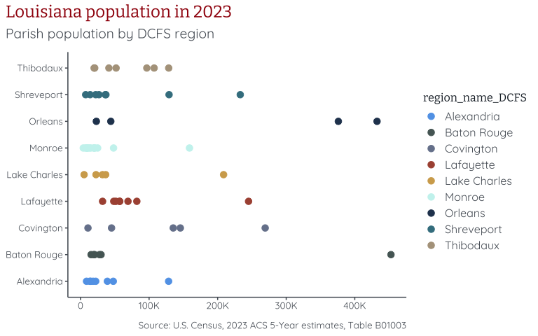

```r
p3 +
  scale_color_manual(values = dcfs_palette()) +
  theme_bc() +
  theme(legend.position = "right")
```

Similarly to the color aesthetics, we can map fill:

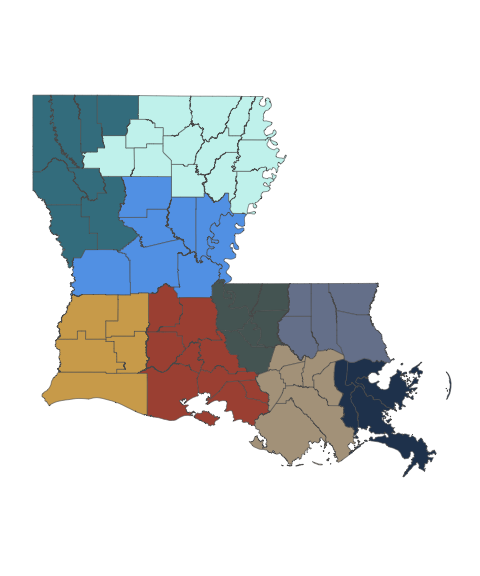

```r
p2 +
  scale_fill_manual(values = dcfs_palette()) +
  theme_bc(void = TRUE) +
  theme(legend.position = "right")
```

This works because we mapped the color/fill aesthetics to the variable ‘region_name_DCFS’ (as you can see in the legend title). Any region color palette will assign the colors to the region name as opposed to the region number by default. In our object `dcfs_regions`, we have the numeric variable ‘region_DCFS’ and the character variable ‘region_name_DCFS’. Other region variables in `parishes` and `louisiana` follow the same pattern.

If you prefer to map color to the region number instead, you’ll need to convert the region’s numeric value to a discrete value (e.g., by using `factor()`) and specify the use of region number rather than region name inside `dcfs_palette()` via the ‘region’ argument. In this step, we can also darken the color for region 9 - Monroe using the ‘darken’ argument.

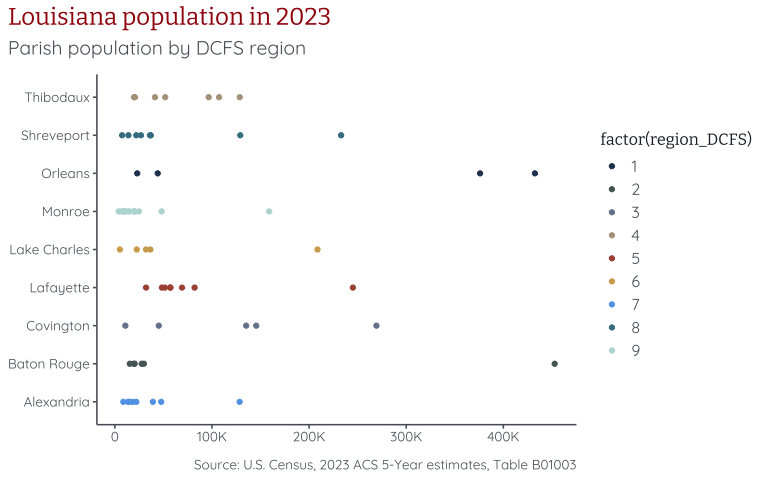

```r
ggplot(louisiana) +
  geom_point(aes(
    x = estimate,
    y = region_name_DCFS,
    color = factor(region_DCFS) # note the use of factor()
    )) +
  scale_x_continuous(labels = label_number(scale_cut = cut_short_scale())) +
  scale_color_manual(values = dcfs_palette(
    region = "number", # use "number" instead of default "name"
    darken = 1 # darken by 1
    )) +
  labs(title = "Louisiana population in 2023",
       subtitle = "Parish population by DCFS region",
       caption = "Source: U.S. Census, 2023 ACS 5-Year estimates, Table B01003",
       y = NULL,
       x = NULL) +
   theme_bc() +
   theme(legend.position = "right")
```

Our legend title is now “factor(region_DCFS)” and the colors are mapped to the numeric counterpart of our region names.

#### Gradient palettes

Gradient palettes, just like the other palettes in blancocentR, generate colors. The default number of colors is 7 but you can adjust the number of colors using the ‘n’ argument. Because the function generates a number of colors, we can’t use it directly for continuous variables, only for discrete variables. However, we can make use of `scale_fill_gradient()` by defining the ‘low’ and ‘high’ arguments like so:

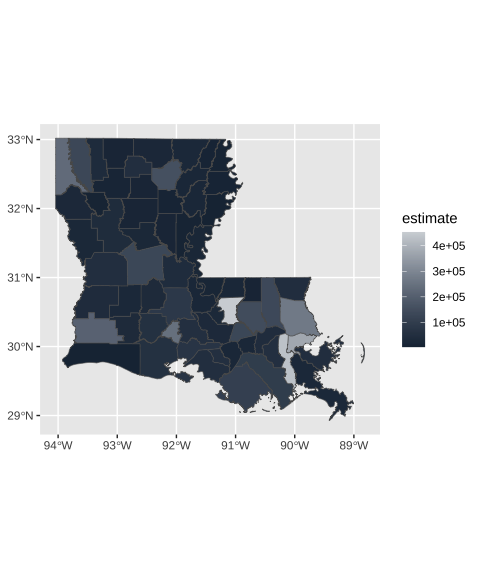

```r
ggplot(louisiana) +
  geom_sf(aes(fill = estimate)) +
  scale_fill_gradient(
  low = la_gradient_palette()[1],
  high = la_gradient_palette()[7]
  )
```

In the previous example, we use the 7th color as ‘high’ because we didn’t define the number of colors the palette generates. By default, this number is 7, so the 7th color is the lightest color. We can achieve the exact same result by generating n colors and selecting the nth value as ‘high’, e.g. using n = 2:

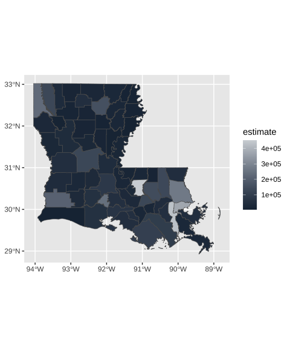

```r
ggplot(louisiana) +
  geom_sf(aes(fill = estimate)) +
  scale_fill_gradient(
  low = la_gradient_palette()[1],
  high = la_gradient_palette(n = 2)[2]
  )
```

*Note:* You could also adjust the base color used to generate the palette with the ‘base’ argument, but that’s not recommended. Under the hood, the function uses `monochromeR::generate_palette()`[^1].

Here are all gradient palettes:

`la_gradient_palette()`

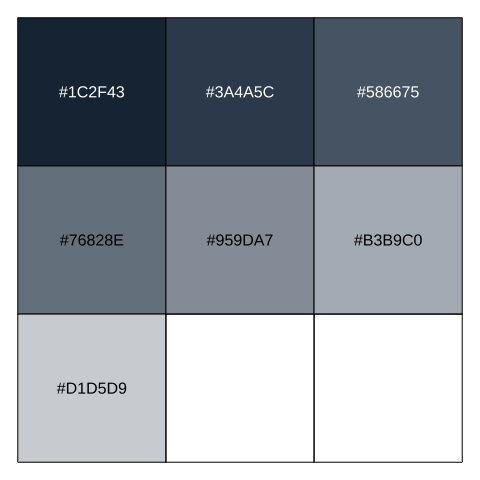

```r
show_col(paste(la_gradient_palette()))
```

`us_gradient_palette()`

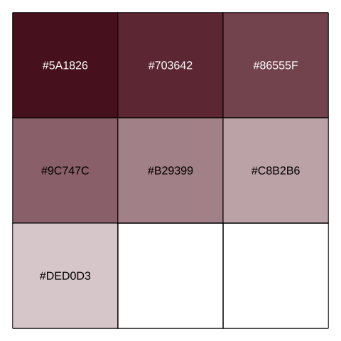

```r
show_col(paste(us_gradient_palette()))
```

`ur_gradient_palette()`

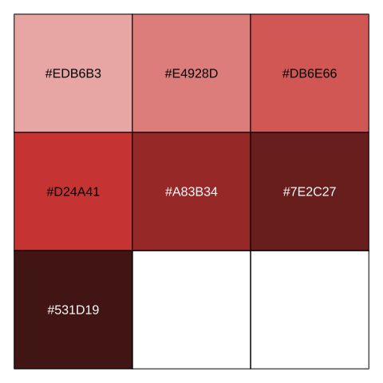

```r
show_col(paste(ur_gradient_palette()))
```

`ru_gradient_palette()`

[figure not shown]

```r
show_col(paste(ru_gradient_palette()))
```

#### Miscellaneous palette

You can access the miscellaneous colors in two ways: 1) via printing the list of named colors and/or individual directly to your console (see Miscellaneous colors), or 2) via the function `misc_palette()`. Just like other palette functions in blancocentR, this function will generate colors, 21 to be exact. You can use these colors directly with ggplot using `scale_*_manual(values = misc_palette())`, depending on how you have mapped your aesthetics. This will work as long as 1) your variable is discrete, and 2) your variable doesn’t exceed 21 distinct levels[^2].

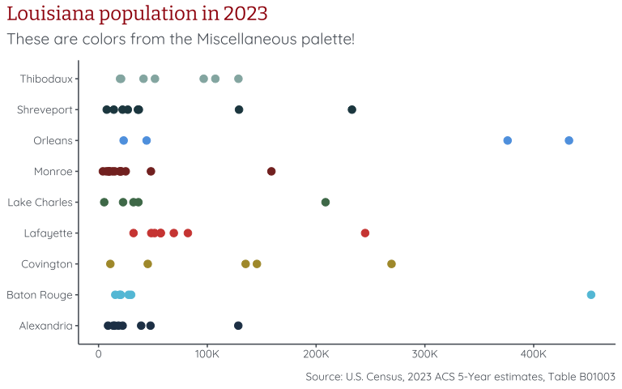

```r
p3 +
  scale_color_manual(values = misc_palette()) +
  theme_bc() +
  theme(legend.position = "none") +
  labs(subtitle = "These are colors from the Miscellaneous palette!")
```

## show_cvd()

Wait, what about this other function we haven’t talked about? `show_cvd()` is a helper function that allows you to quickly compare what your selected colors might look like to someone with color vision deficiency, or if you print them in gray-scale.

The output shows 5 rows:

1. your original input colors
2. deuteranope simulation (green cone cells defective)
3. protanope simulation (red cone cells defective)
4. tritanope simulation (blue cone cells defective)
5. desaturated (gray-scale)

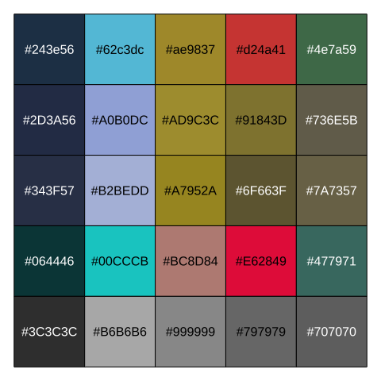

```r
show_cvd(misc_palette(n = 5))
```

*Note:* Under the hood, the function uses `scales::show_col()`[^3] and functions from the {colorspace}[^4] package.

[^1]: See {monochromeR} on [github](https://github.com/cararthompson/monochromeR).
[^2]: If your variable does exceed 21 distinct levels, you really shouldn’t use colors to distinguish them!
[^3]: See the {scales} [documentation site](https://scales.r-lib.org).
[^4]: See the {colorspace} [documentation website](https://colorspace.r-forge.r-project.org).